# Análisis de patrón de puntos en R

# Análisis de patrones de puntos “marcados”

Como vimos en la sesión teórica, un dataset de patrón de puntos contiene una serie de eventos, que son los objetos de interés (árboles, muestras de suelo, nidos, crímenes). Sin embargo a menudo estos puntos llevan asociada alguna variable de interés, que puede ser numérica (diámetro, pH del suelo…) o categórica (especie, tipo de suelo…). Estas variables se llaman *marcas* y los objetos que contienen puntos con marcas asociadas se llaman patrones de puntos *marcados*.

Recordemos que los patrones de puntos tienen propiedades *de primer orden*, relacionadas con la intensidad (o densidad) de eventos a lo largo y ancho del área de estudio, y propiedades *de segundo orden*, que hacen referencia a la dependencia espacial entre los eventos.

Al entrar en juego las marcas, el tipo de preguntas que nos podemos hacer cuando tenemos puntos marcados es variado. Por ejemplo: ¿están relacionadas las ocurrencias de un tipo de evento (por ejemplo, una especie) con las de otro? La distribución de uno de los tipos de evento explica la de otro?

Ahora veremos cómo calcular modelos dependientes de la densidad (mediante kernel) para puntos con diferentes marcas, así como las variantes de los principales métodos dependientes de la distancia (funciones $F$, $G$, $K$ y $L$). Pero antes, veamos algo más sobre los ficheros de patrón de puntos marcados:

## Marcas numéricas

Las marcas de un fichero de patrón de puntos pueden ser de tipo numérico o categórico. Si recordamos del inicio, el fichero `longleaf` contiene valores de diámetro de los árboles, y R ya nos indica que contiene marcas numéricas:

```r
longleaf
```

```
Marked planar point pattern: 584 points
marks are numeric, of storage type  'double'
window: rectangle = [0, 200] x [0, 200] metres
```

Además, ahora podemos acceder a los valores de las marcas dentro de `longleaf`:

```r
    longleaf$marks
```

```
  [1] 32.9 53.5 68.0 17.7 36.9 51.6 66.4 17.7 21.9 25.7 25.5 28.3 11.2 33.8  2.5
 [16]  4.2  2.5 31.2 16.4 53.2 67.3 37.8 49.9 46.3 40.5 57.7 58.0 54.9 25.3 18.4
 [31] 72.0 31.4 55.1 36.0 28.4 24.8 44.1 50.9 47.5 58.0 36.9 65.6 52.9 39.5 42.7
 [46] 44.4 40.3 53.5 44.2 53.8 38.0 48.3 42.9 40.6 34.5 45.7 51.8 52.0 44.5 35.6
 [61] 19.2 43.5 33.7 43.3 36.6 46.3 48.3 20.4 40.5 44.0 40.9 51.0 36.5 42.1 15.6
 [76] 18.5 43.0 28.9 21.3 30.9 42.7 37.6 47.1 44.6 44.3 26.1 25.9 41.4 59.5 26.1
 [91] 11.4 33.4 35.8 54.4 33.6 35.5  7.4 36.6 19.1 34.9 37.3 16.3 39.1 36.5 25.0
[106] 46.8 18.7 23.2 20.4 42.3 38.1 17.9 39.7 14.5 33.5 56.0 66.1 26.3 44.8 24.2
[121] 39.0 15.1 35.6 21.6 17.2 22.3 18.2 55.6 23.3 27.0 50.1 45.5 47.2 37.8 31.9
[136] 38.5 23.8 46.3  2.8  3.2  5.8  3.5  2.3  3.8  3.2  4.4  3.9  7.8  4.7  4.8
[151] 44.1 51.5 51.6 33.3 13.3  5.7  3.3 45.9 32.6 11.4  9.1  5.2  4.9 42.0 32.0
[166] 32.8 22.0 20.8  7.3  3.0  2.2  2.2  2.2 59.4 48.1 51.5 50.3  2.9 19.1 15.1
[181] 21.7 42.4 40.2 37.4 40.1 39.5 32.5 39.5 35.6 44.1 42.2 39.4 35.5 39.1  9.5
[196] 48.4 31.9 30.7 15.0 24.5 15.0 22.2 27.5 10.8 26.2 10.2 18.9 44.2 13.8 16.7
[211] 35.7 12.1 35.4 32.7 30.1 28.4 16.5 12.7  5.5  2.5  3.0  3.2  3.2  4.0  3.6
```

[output cut: 24 more lines]

Y si ploteamos:

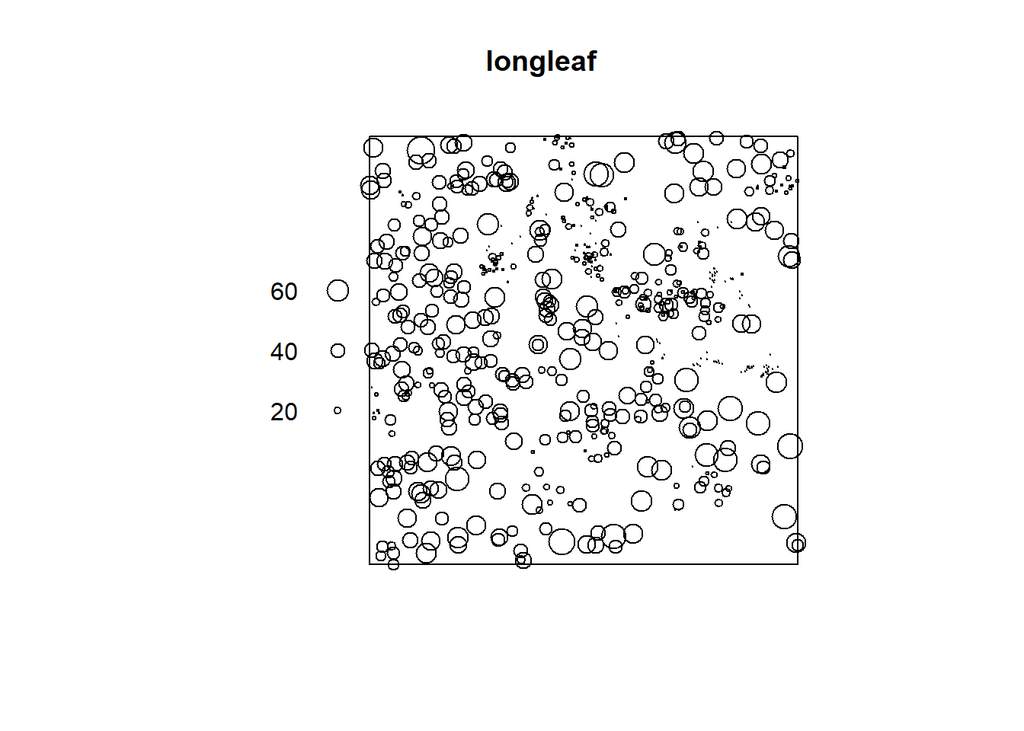

```r
plot(longleaf)
```

Vemos que por defecto, el tamaño de los círculos es proporcional a la variable de “marca”, en este caso el diámetro. Podemos cambiar este comportamiento por defecto marcando la opción `use.marks` a `FALSE`

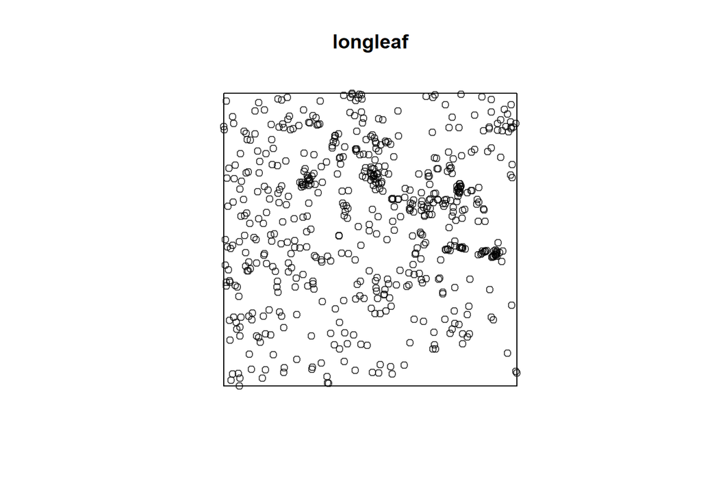

```r
plot(longleaf, use.marks = FALSE)
```

Aunque se pueden realizar algunos cálculos con ficheros ppp con marcas numéricas, en realidad esto cae más dentro del campo de la autocorrelación espacial, por lo que no lo trataremos aquí.

## Marcas categóricas

El segundo tipo de marcas posible que podemos encontrar son las marcas categóricas. Es el caso del fichero `lansing`:

```r
lansing
```

```
Marked planar point pattern: 2251 points
Multitype, with levels = blackoak, hickory, maple, misc, redoak, whiteoak
window: rectangle = [0, 1] x [0, 1] units (one unit = 924 feet)
```

```r
head(lansing$marks)
```

```
[1] blackoak blackoak blackoak blackoak blackoak blackoak
Levels: blackoak hickory maple misc redoak whiteoak
```

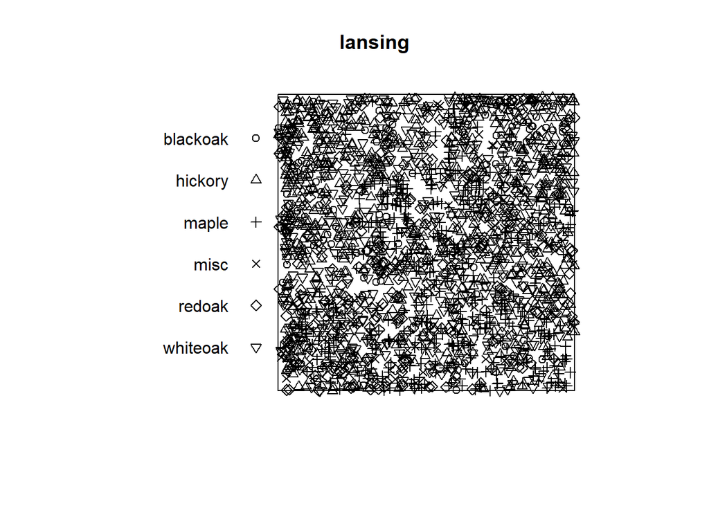

```r
plot(lansing)
```

Por defecto nos separa los distintos niveles de la marca (en este caso la especie) mediante símbolos, pero podemos modificarlo:

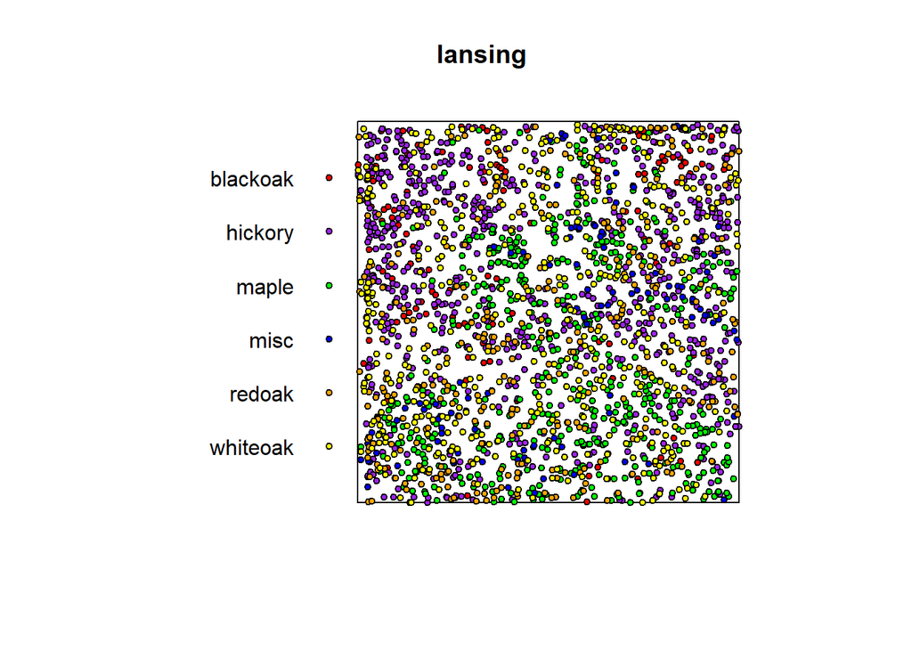

```r
plot(lansing, cex = 0.7, pch = 21, bg = c("red", "purple", "green", "blue", "orange", "yellow"))
```

También podemos obviarlo con la opción `use.marks = FALSE`

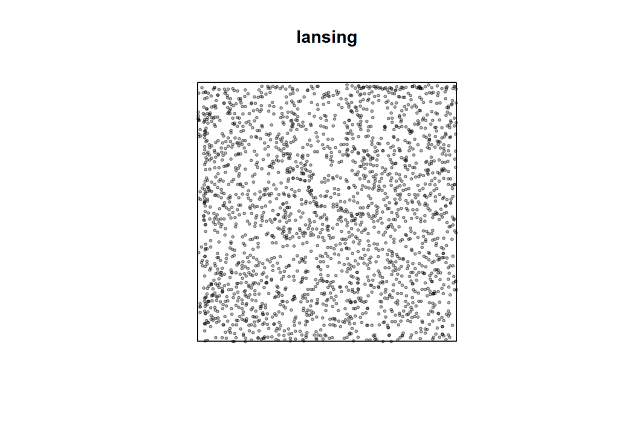

```r
plot(lansing, use.marks = FALSE, pch =19, cex = 0.5)
```

## Crear objetos ppp con marcas

Como hemos comentado, las funciones con las que trabajaremos no utilizan ninguno de los formatos de ráster o vectorial que conocemos, sino que utilizan objetos de clase `ppp` (planar point pattern). Los datasets que usaremos ya vienen en este formato, pero esto no es lo habitual, por lo que en esta sección veremos cómo generar objetos de este tipo a partir de datasets normales.

Un objeto `ppp` contiene las coordenadas de los puntos y una”ventana” de análisis (área de estudio). Vamos a cargar los datos ya en el formato necesario. En este caso cargaremos los puntos de un fichero separado por comas disponible en el campus virtual, y llamado `finland.csv`, que contiene la ubicación de árboles de 4 especies en una parcela de 20x20 m en Finlandia.

```r
finland_trees <- read.csv("./data/finland/finland.csv")
```

Podemos ver que el objeto `finland_trees` tiene 3 columnas, una contiene las coordenadas X, otra las Y, y el tercero contiene la especie de cada árbol. Podemos observarlo mediante:

```r
head(finland_trees)
```

```
          x        y species
1 1.9119408 19.52381    pine
2 1.1462073 18.29303    pine
3 0.4761905 16.76923    pine
4 3.5391237 19.11355    pine
5 2.7255319 17.82417    pine
6 2.2469492 16.24175    pine
```

Para crear un objeto `ppp` necesitamos usar la función `ppp()`. Si miramos la ayuda de la función (`?ppp`) vemos que esta función requiere 4 tipos de información: las coordenadas X, las Y, el tamaño de la “ventana” (la región a estudiar) y las marcas, si es que las hay (los valores asociados a cada evento). Vamos a crear un objeto `ppp` a partir de `finland_trees`:

```r
finland <- ppp(x = finland_trees$x, y = finland_trees$y,
               window = owin(c(0,20), c(0,20), unitname = "meters"),
               marks = factor(finland_trees$species))
```

Con el código de arriba definimos las coordenadas x e y para el objeto ppp a partir de las columnas del data frame. La parte del código que dice `window = owin` define el rango de x e y alrededor de los puntos, y el comando `marks =` define los valores de las marcas, aunque esto último es opcional.

## Análisis exploratorio/descriptivo

¿Cuántos eventos tiene el dataset `finland`? ¿Cuál es el área de estudio? ¿Cuántas especies diferentes contiene la parcela? ¿Cuál es la densidad relativa de cada una de ellas?

Las dos primeras son preguntas que ya sabemos responder de ejercicios anteriores. Sin embargo ahora vemos que la función `summary()` nos devuelve información por marcas:

```r
summary(finland)
```

```
Marked planar point pattern:  168 points
Average intensity 0.42 points per square meters

Coordinates are given to 15 decimal places

Multitype:
      frequency  proportion intensity
aspen         1 0.005952381    0.0025
birch        17 0.101190500    0.0425
pine        128 0.761904800    0.3200
rowan        22 0.130952400    0.0550

Window: rectangle = [0, 20] x [0, 20] meters
Window area = 400 square meters
Unit of length: 1 meters
```

Del mismo modo, el plot “normal” puede resultar confuso, pero podemos pedirle que nos represente la distribución de cada tipo de evento (en este caso, cada especie):

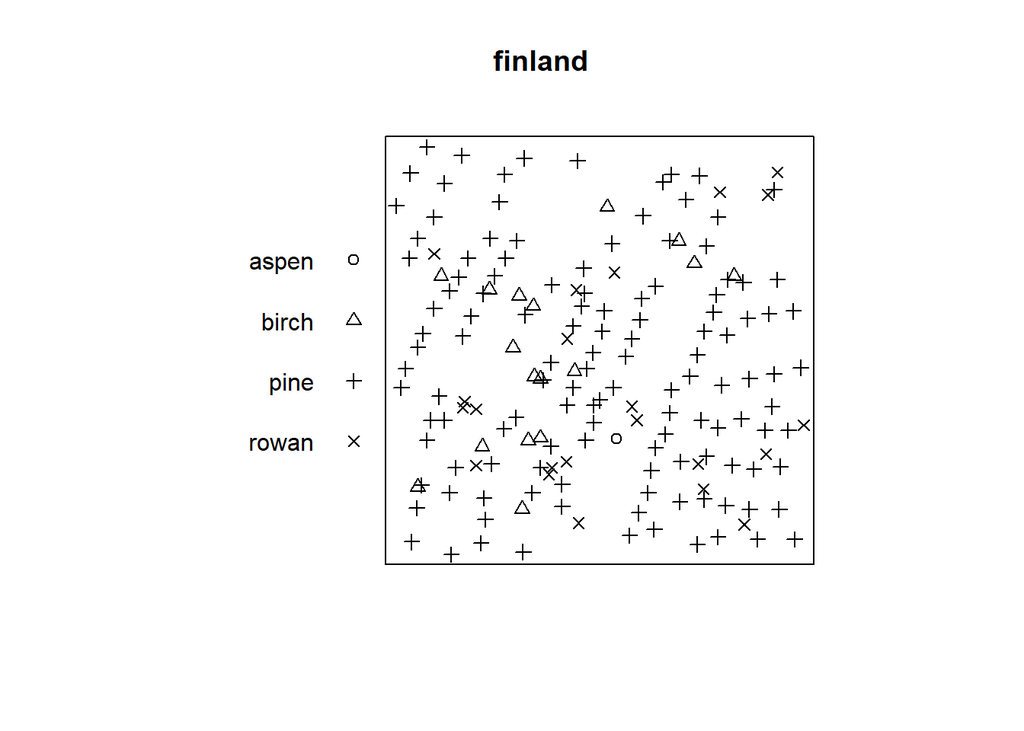

```r
plot(finland)
```

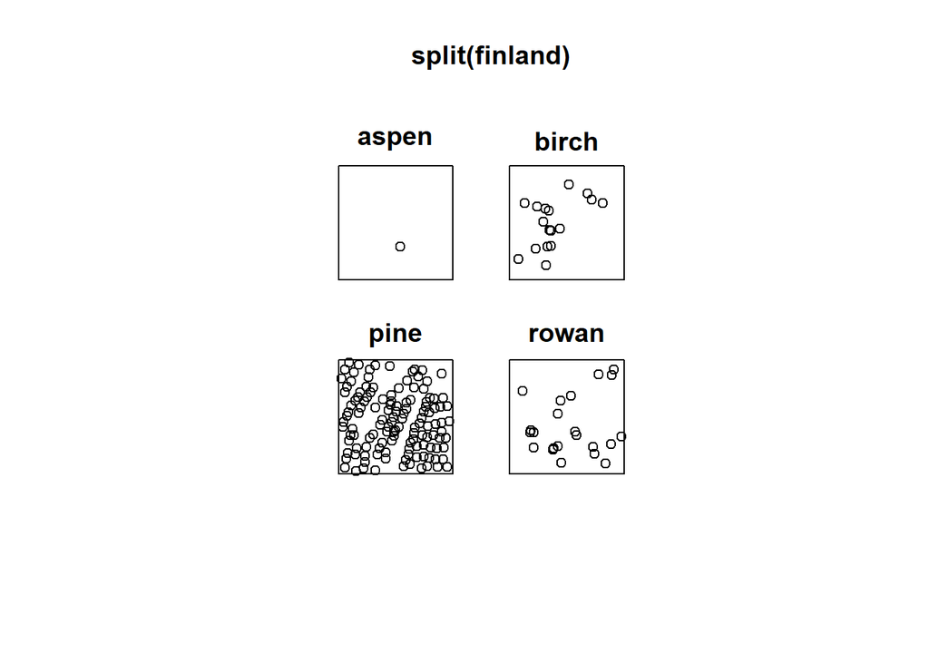

```r
plot(split(finland))
```

## Efectos de primer orden (dependientes de la densidad)

Vamos a ajustar un análisis de densidad en kernel (ventana móvil para las especies diferentes de las contenidas en nuestra muestra). En realidad es muy sencillo, aprovechando la función `split()` que hemos visto antes:

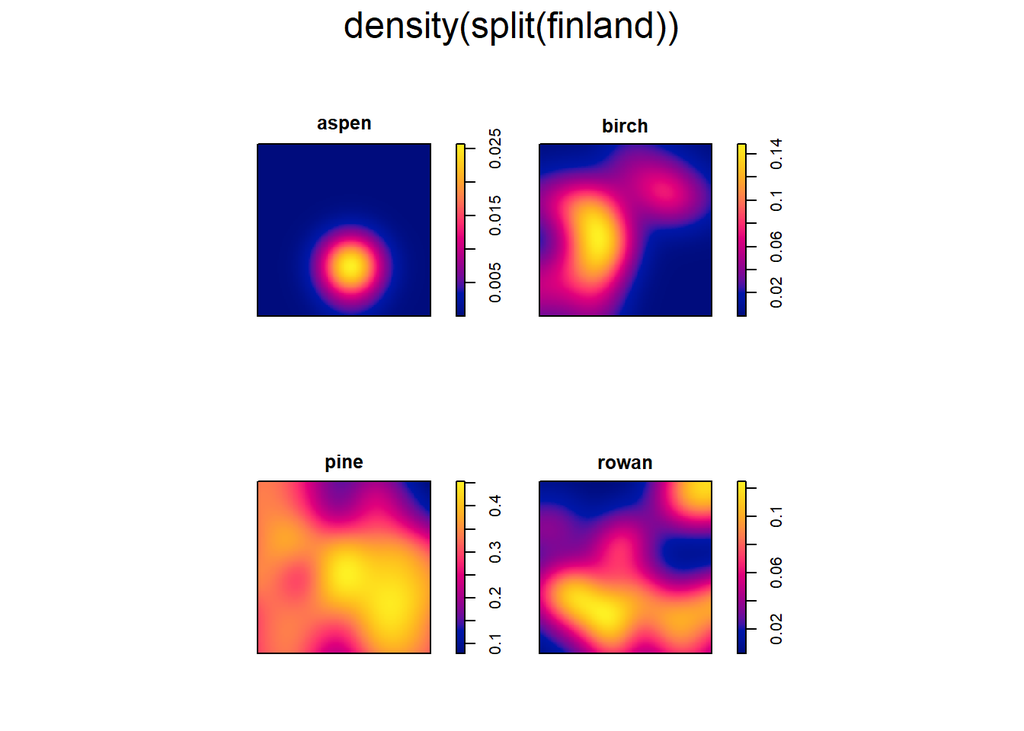

```r
plot(density(split(finland)))
```

La proporción relativa de la intensidad de cada especie se puede calcular, para hacer que las intensidades estén todas en la misma escala y se puedan comparar los valores:

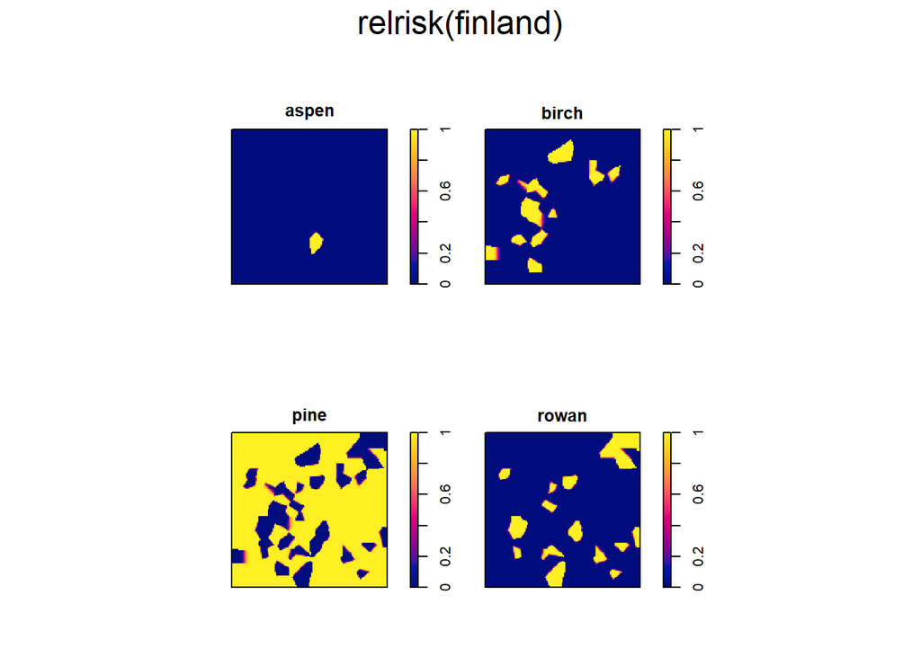

```r
plot(relrisk(finland), zlim = c(0, 1))
```

Ahora los valores son más comparables entre especies, y vemos de manera muy clara la abundancia de pinos, y los pocos chopos (aspen) que hay. Basado en los mapas de densidad, ¿véis alguna especie que se asocie con otra? ¿Y algún tipo de proceso de segregación entre especies?

## Efectos de segundo orden (dependientes de la distancia)

Igual que en los eventos de puntos sin marcas, podemos testar las asociaciones entre los distintos tipos de eventos de manera más formal mediante las funciones $G$, $F$, $K$ y $L$. Para cada una de las funciones vistas antes (`Gest`, `Fest`, `Kest` y `Lest`) existe su variante de tipo cruzado (cross-type), que compara las distribuciones para dos valores de la variable de marca.

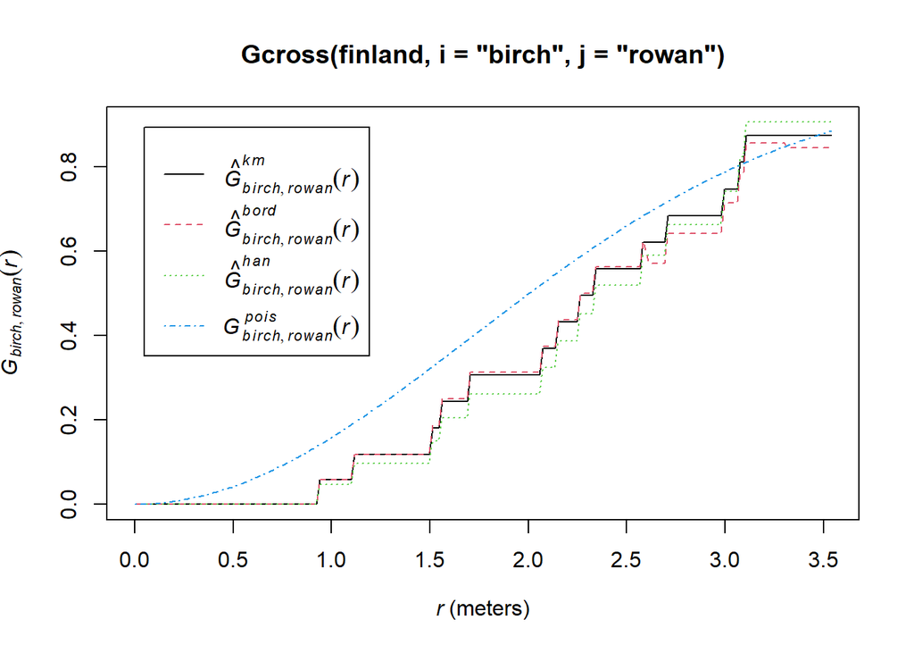

```r
plot(Gcross(finland, i = "birch", j = "rowan"))
```

La interpretación es similar a la que hemos visto hasta ahora, de manera que los valores por debajo de la curva teórica indica segregación entre las especies, mientras que valores por encima indican agrupación.

Nótese que debemos especificar los niveles de la muestra a comparar, si no tomará por defecto los dos primeros (ya que las comparaciones sólo pueden hacerse dos a dos)

También podemos construir los intervalos de confianza de manera análoga:

```r
 G <- envelope(finland, Gcross, i= "birch", j = "rowan",
               nsim = 10)
```

```
Generating 10 simulations of CSR  ...
1, 2, 3, 4, 5, 6, 7, 8, 9,
10.

Done.
```

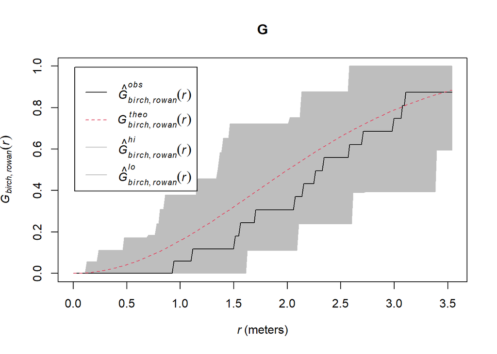

```r
plot(G)
```

El resto de funciones asociadas a las propiedades de segundo orden pueden construirse de forma análoga:

```r
# Función K
 K <- envelope(finland, Kcross, i= "birch", j = "rowan",nsim = 10)
```

```
Generating 10 simulations of CSR  ...
1, 2, 3, 4, 5, 6, 7, 8, 9,
10.

Done.
```

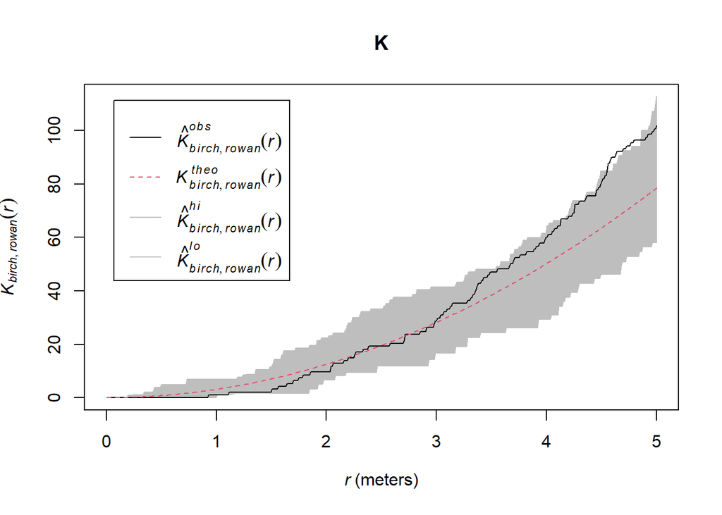

```r
plot(K)
```

```r
# Función L
L <- envelope(finland, Lcross, i= "birch", j = "rowan", nsim = 10)
```

```
Generating 10 simulations of CSR  ...
1, 2, 3, 4, 5, 6, 7, 8, 9,
10.

Done.
```

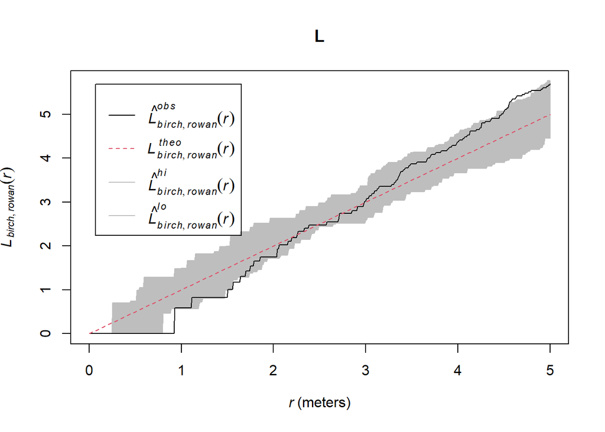

```r
plot(L)
```

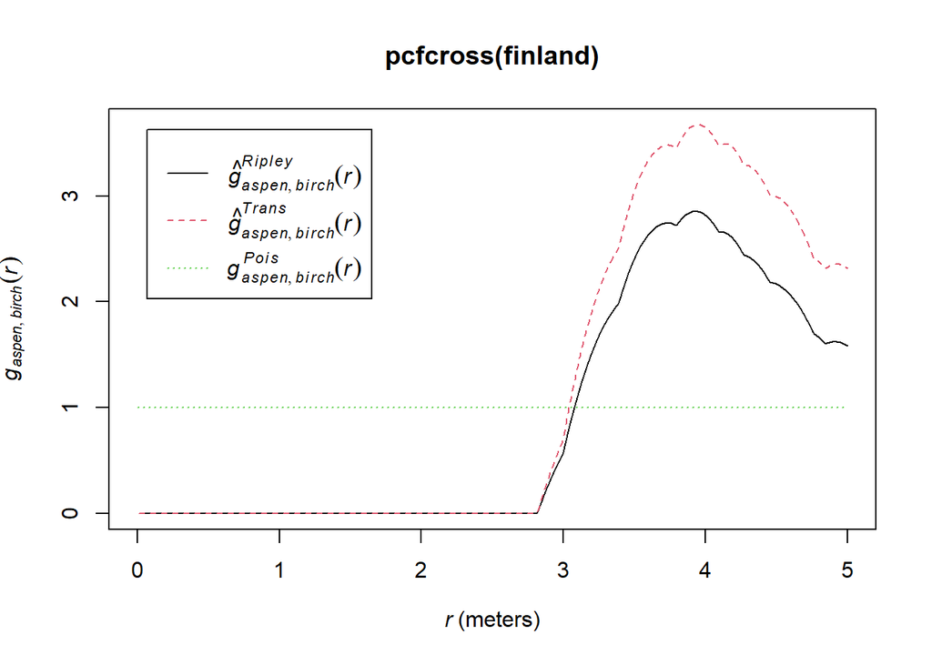

```r
# Función de correlación de pares
plot(pcfcross(finland))
```

# Conclusiones

Hemos visto como analizar patrones de puntos tanto univariantes como multivariantes (con varios niveles), de manera que hemos aprendido a determinar si la distribución de una serie de puntos es aleatoria, agrupada o dispersa, y a comparar las distribuciones de dos especies mediante diversos estadísticos. Por supuesto, esto es sólo la punta del iceberg de la potencialidad de este tipo de análisis, pero supone una buena base que podemos utilizar para analizar diferentes tipos de datos.